# Introduction

This is the workbook component of the "Indexing, selecting, assigning" section. For the reference component, [**click here**](https://www.kaggle.com/residentmario/indexing-selecting-assigning-reference).

Selecting specific values of a `pandas` `DataFrame` or `Series` to work on is an implicit step in almost any data operation you'll run, so one of the first things you need to learn in working with data in Python is how to go about selecting the data points relevant to you quickly and effectively.

In this set of exercises we will work on exploring the [Wine Reviews dataset](https://www.kaggle.com/zynicide/wine-reviews).

# Relevant Resources

- **[Quickstart to indexing and selecting data](https://www.kaggle.com/residentmario/indexing-and-selecting-data/)**
- [Indexing and Selecting Data](https://pandas.pydata.org/pandas-docs/stable/indexing.html) section of pandas documentation http://archive.is/Fdoxm
- [Pandas Cheat Sheet](https://assets.datacamp.com/blog_assets/PandasPythonForDataScience.pdf)

# Set Up

**Fork this notebook using the button towards the top of the screen.**

Run the following cell to load your data and some utility functions

```python
import pandas as pd
import seaborn as sns

import sys
sys.path.append('../input/advanced-pandas-exercises/')
from indexing_selecting_assigning import *

reviews = pd.read_csv("../input/wine-reviews/winemag-data-130k-v2.csv", index_col=0)
pd.set_option("display.max_rows", 5)
```

Look at an overview of your data by running the following line

```python
reviews.head()
```

|  | country | description | designation | points | price | province | region_1 | region_2 | taster_name | taster_twitter_handle | title | variety | winery |
| --- | --- | --- | --- | --- | --- | --- | --- | --- | --- | --- | --- | --- | --- |
| 0 | Italy | Aromas include tropical fruit, broom, brimston... | Vulkà Bianco | 87 | NaN | Sicily & Sardinia | Etna | NaN | Kerin O’Keefe | @kerinokeefe | Nicosia 2013 Vulkà Bianco (Etna) | White Blend | Nicosia |
| 1 | Portugal | This is ripe and fruity, a wine that is smooth... | Avidagos | 87 | 15.0 | Douro | NaN | NaN | Roger Voss | @vossroger | Quinta dos Avidagos 2011 Avidagos Red (Douro) | Portuguese Red | Quinta dos Avidagos |
| 2 | US | Tart and snappy, the flavors of lime flesh and... | NaN | 87 | 14.0 | Oregon | Willamette Valley | Willamette Valley | Paul Gregutt | @paulgwine | Rainstorm 2013 Pinot Gris (Willamette Valley) | Pinot Gris | Rainstorm |
| 3 | US | Pineapple rind, lemon pith and orange blossom ... | Reserve Late Harvest | 87 | 13.0 | Michigan | Lake Michigan Shore | NaN | Alexander Peartree | NaN | St. Julian 2013 Reserve Late Harvest Riesling ... | Riesling | St. Julian |
| 4 | US | Much like the regular bottling from 2012, this... | Vintner's Reserve Wild Child Block | 87 | 65.0 | Oregon | Willamette Valley | Willamette Valley | Paul Gregutt | @paulgwine | Sweet Cheeks 2012 Vintner's Reserve Wild Child... | Pinot Noir | Sweet Cheeks |

# Checking Answers

You can check your answers in each of the exercises that follow using the `check_qN` function provided in the code cell above (replacing `N` with the number of the exercise). For example here's how you would check an incorrect answer to exercise 1:

```python
check_q1(pd.DataFrame())
```

```
False
```

For the first set of questions, if you use `check_qN` on your answer, and your answer is right, a simple `True` value will be returned.

For the second set of questions, using this function to check a correct answer will present you will an informative graph!

If you get stuck, use `answer_qN` function to print the answer outright.

# Exercises

**Exercise 1**: Select the `description` column from `reviews`.

```python
reviews.description
```

```
0         Aromas include tropical fruit, broom, brimston...
1         This is ripe and fruity, a wine that is smooth...
                                ...
129969    A dry style of Pinot Gris, this is crisp with ...
129970    Big, rich and off-dry, this is powered by inte...
Name: description, Length: 129971, dtype: object
```

```python
print(check_q1(reviews.description))
print('-------')
print(answer_q1())
```

```
True
-------
reviews.description
None
```

**Exercise 2**: Select the first value from the description column of `reviews`.

```python
reviews.description[0]
```

```
"Aromas include tropical fruit, broom, brimstone and dried herb. The palate isn't overly expressive, offering unripened apple, citrus and dried sage alongside brisk acidity."
```

```python
print(check_q2(reviews.description[0]))
print('-------')
print(answer_q2())
```

```
True
-------
reviews.description[0]
None
```

**Exercise 3**: Select the first row of data (the first record) from `reviews`. Hint: from this exercise onwards I strongly recommend using `loc` or `iloc`.

```python
reviews.iloc[0]
```

```
country                                                    Italy
description    Aromas include tropical fruit, broom, brimston...
                                     ...
variety                                              White Blend
winery                                                   Nicosia
Name: 0, Length: 13, dtype: object
```

```python
print(check_q3(reviews.iloc[0]))
print('-------')
print(answer_q3())
```

```
True
-------
reviews.iloc[0]
None
```

**Exercise 4**: Select the first 10 values from the `description` column in `reviews`. Hint: format your output as a `pandas` `Series`.

```python
reviews.iloc[0:10, 1]
```

```
0    Aromas include tropical fruit, broom, brimston...
1    This is ripe and fruity, a wine that is smooth...
                           ...
8    Savory dried thyme notes accent sunnier flavor...
9    This has great depth of flavor with its fresh ...
Name: description, Length: 10, dtype: object
```

```python
print(check_q4(reviews.iloc[0:10, 1]))
print('-------')
print(answer_q4())
```

```
True
-------
reviews.iloc[0:10, 1]
None
```

**Exercise 5**: Select the records with the `1`, `2`, `3`, `5`, and `8` row index positions. In other words, generate the following`DataFrame`:

[figure not shown]

```python
reviews.iloc[[1,2,3,5,8]]
```

|  | country | description | designation | points | price | province | region_1 | region_2 | taster_name | taster_twitter_handle | title | variety | winery |
| --- | --- | --- | --- | --- | --- | --- | --- | --- | --- | --- | --- | --- | --- |
| 1 | Portugal | This is ripe and fruity, a wine that is smooth... | Avidagos | 87 | 15.0 | Douro | NaN | NaN | Roger Voss | @vossroger | Quinta dos Avidagos 2011 Avidagos Red (Douro) | Portuguese Red | Quinta dos Avidagos |
| 2 | US | Tart and snappy, the flavors of lime flesh and... | NaN | 87 | 14.0 | Oregon | Willamette Valley | Willamette Valley | Paul Gregutt | @paulgwine | Rainstorm 2013 Pinot Gris (Willamette Valley) | Pinot Gris | Rainstorm |
| 3 | US | Pineapple rind, lemon pith and orange blossom ... | Reserve Late Harvest | 87 | 13.0 | Michigan | Lake Michigan Shore | NaN | Alexander Peartree | NaN | St. Julian 2013 Reserve Late Harvest Riesling ... | Riesling | St. Julian |
| 5 | Spain | Blackberry and raspberry aromas show a typical... | Ars In Vitro | 87 | 15.0 | Northern Spain | Navarra | NaN | Michael Schachner | @wineschach | Tandem 2011 Ars In Vitro Tempranillo-Merlot (N... | Tempranillo-Merlot | Tandem |
| 8 | Germany | Savory dried thyme notes accent sunnier flavor... | Shine | 87 | 12.0 | Rheinhessen | NaN | NaN | Anna Lee C. Iijima | NaN | Heinz Eifel 2013 Shine Gewürztraminer (Rheinhe... | Gewürztraminer | Heinz Eifel |

```python
print(check_q5(reviews.iloc[[1,2,3,5,8]]))
print('-------')
print(answer_q5())
```

```
True
-------
reviews.iloc[[1, 2, 3, 5, 8]]
None
```

**Exercise 6**: Select the `country`, `province`, `region_1`, and `region_2` columns of the records with the `0`, `1`, `10`, and `100` index positions. In other words, generate the following `DataFrame`:

[figure not shown]

```python
reviews.loc[[0, 1, 10, 100], ['country', 'province', 'region_1', 'region_2']]
```

|  | country | province | region_1 | region_2 |
| --- | --- | --- | --- | --- |
| 0 | Italy | Sicily & Sardinia | Etna | NaN |
| 1 | Portugal | Douro | NaN | NaN |
| 10 | US | California | Napa Valley | Napa |
| 100 | US | New York | Finger Lakes | Finger Lakes |

```python
print(check_q6(reviews.loc[[0, 1, 10, 100], ['country', 'province', 'region_1', 'region_2']]))
print('-------')
print(answer_q6())
```

```
True
-------
reviews.loc[[0, 1, 10, 100], ['country', 'province', 'region_1', 'region_2']]
None
```

**Exercise 7**: Select the `country` and `variety` columns of the first 100 records.

Hint: you may use `loc` or `iloc`. When working on the answer this question and the several of the ones that follow, keep the following "gotcha" described in the reference for this tutorial section:

> `iloc` uses the Python stdlib indexing scheme, where the first element of the range is included and the last one excluded. So `0:10` will select entries `0,...,9`. `loc`, meanwhile, indexes inclusively. So `0:10` will select entries `0,...,10`.

> [...]

```python
reviews.loc[0:100, ['country', 'variety']]
```

|  | country | variety |
| --- | --- | --- |
| 0 | Italy | White Blend |
| 1 | Portugal | Portuguese Red |
| ... | ... | ... |
| 99 | US | Bordeaux-style Red Blend |
| 100 | US | Pinot Gris |

101 rows × 2 columns

```python
print(check_q7(reviews.loc[0:100, ['country', 'variety']]))
print('-------')
print(answer_q7())
```

```
True
-------
reviews.loc[0:100, ['country', 'variety']]
None
```

**Exercise 8**: Select wines made in `Italy`. Hint: `reviews.country` equals what?

```python
reviews.loc[reviews.country == 'Italy']
```

|  | country | description | designation | points | price | province | region_1 | region_2 | taster_name | taster_twitter_handle | title | variety | winery |
| --- | --- | --- | --- | --- | --- | --- | --- | --- | --- | --- | --- | --- | --- |
| 0 | Italy | Aromas include tropical fruit, broom, brimston... | Vulkà Bianco | 87 | NaN | Sicily & Sardinia | Etna | NaN | Kerin O’Keefe | @kerinokeefe | Nicosia 2013 Vulkà Bianco (Etna) | White Blend | Nicosia |
| 6 | Italy | Here's a bright, informal red that opens with ... | Belsito | 87 | 16.0 | Sicily & Sardinia | Vittoria | NaN | Kerin O’Keefe | @kerinokeefe | Terre di Giurfo 2013 Belsito Frappato (Vittoria) | Frappato | Terre di Giurfo |
| ... | ... | ... | ... | ... | ... | ... | ... | ... | ... | ... | ... | ... | ... |
| 129961 | Italy | Intense aromas of wild cherry, baking spice, t... | NaN | 90 | 30.0 | Sicily & Sardinia | Sicilia | NaN | Kerin O’Keefe | @kerinokeefe | COS 2013 Frappato (Sicilia) | Frappato | COS |
| 129962 | Italy | Blackberry, cassis, grilled herb and toasted a... | Sàgana Tenuta San Giacomo | 90 | 40.0 | Sicily & Sardinia | Sicilia | NaN | Kerin O’Keefe | @kerinokeefe | Cusumano 2012 Sàgana Tenuta San Giacomo Nero d... | Nero d'Avola | Cusumano |

19540 rows × 13 columns

```python
print(check_q8(reviews.loc[reviews.country == 'Italy']))
print('-------')
print(answer_q8())
```

```
True
-------
reviews.loc[reviews.country == 'Italy']
None
```

**Exercise 9**: Select wines whose `region_2` is not `NaN`.

```python
reviews.loc[reviews.region_2.notnull()]
```

|  | country | description | designation | points | price | province | region_1 | region_2 | taster_name | taster_twitter_handle | title | variety | winery |
| --- | --- | --- | --- | --- | --- | --- | --- | --- | --- | --- | --- | --- | --- |
| 2 | US | Tart and snappy, the flavors of lime flesh and... | NaN | 87 | 14.0 | Oregon | Willamette Valley | Willamette Valley | Paul Gregutt | @paulgwine | Rainstorm 2013 Pinot Gris (Willamette Valley) | Pinot Gris | Rainstorm |
| 4 | US | Much like the regular bottling from 2012, this... | Vintner's Reserve Wild Child Block | 87 | 65.0 | Oregon | Willamette Valley | Willamette Valley | Paul Gregutt | @paulgwine | Sweet Cheeks 2012 Vintner's Reserve Wild Child... | Pinot Noir | Sweet Cheeks |
| ... | ... | ... | ... | ... | ... | ... | ... | ... | ... | ... | ... | ... | ... |
| 129952 | US | This Zinfandel from the eastern section of Nap... | NaN | 90 | 22.0 | California | Chiles Valley | Napa | Virginie Boone | @vboone | Houdini 2011 Zinfandel (Chiles Valley) | Zinfandel | Houdini |
| 129967 | US | Citation is given as much as a decade of bottl... | NaN | 90 | 75.0 | Oregon | Oregon | Oregon Other | Paul Gregutt | @paulgwine | Citation 2004 Pinot Noir (Oregon) | Pinot Noir | Citation |

50511 rows × 13 columns

```python
print(check_q9(reviews.loc[reviews.region_2.notnull()]))
print('-------')
print(answer_q9())
```

```
True
-------
reviews.loc[reviews.region_2.notnull()]
None
```

The remaining exercises are visual.

**Exercise 10**: Select the `points` column.

```python
reviews.points
```

```
0         87
1         87
          ..
129969    90
129970    90
Name: points, Length: 129971, dtype: int64
```

```
AxesSubplot(0.125,0.125;0.775x0.755)
```

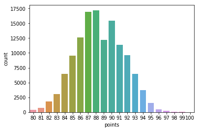

```python
print(check_q10(reviews.points))
```

```python
print(answer_q10())
```

```
reviews.points
None
```

**Exercise 11**: Select the `points` column for the first 1000 wines.

```python
reviews.loc[:1000, 'points']
```

```
0       87
1       87
        ..
999     88
1000    88
Name: points, Length: 1001, dtype: int64
```

```
AxesSubplot(0.125,0.125;0.775x0.755)
```

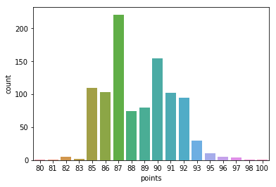

```python
print(check_q11(reviews.loc[:1000, 'points']))
```

```python
print(answer_q11())
```

```
reviews.loc[:1000, 'points']
None
```

**Exercise 12**: Select the `points` column for the last 1000 wines.

```python
reviews.iloc[-1000:, 3]
```

```
128971    91
128972    91
          ..
129969    90
129970    90
Name: points, Length: 1000, dtype: int64
```

```
AxesSubplot(0.125,0.125;0.775x0.755)
```

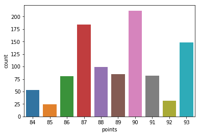

```python
print(check_q12(reviews.iloc[-1000:, 3]))
```

```python
print(answer_q12())
```

```
reviews.iloc[-1000:, 3]
None
```

**Exercise 13**: Select the `points` column, but only for wines made in Italy.

```python
reviews[reviews.country == "Italy"].points
```

```
0         87
6         87
          ..
129961    90
129962    90
Name: points, Length: 19540, dtype: int64
```

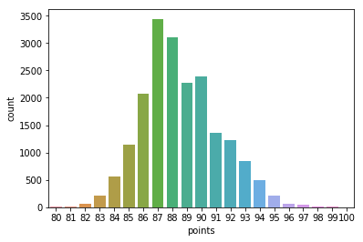

```python
check_q13(reviews[reviews.country == "Italy"].points)
```

```python
print(answer_q13())
```

```
reviews[reviews.country == "Italy"].points
None
```

**Exercise 14**: Who produces more above-averagely good wines, France or Italy? Select the `country` column, but only when said `country` is one of those two options, *and* the `points` column is greater than or equal to 90.

Your output should look roughly like this:

```
119       France
120        Italy
           ...
129969    France
129970    France
Name: country, Length: 15840, dtype: object
```

```python
reviews[reviews.country.isin(["Italy", "France"]) & (reviews.points >= 90)].country
```

```
119       France
120        Italy
           ...
129969    France
129970    France
Name: country, Length: 15840, dtype: object
```

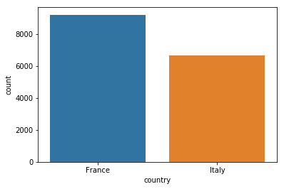

```python
check_q14(reviews[reviews.country.isin(["Italy", "France"]) & (reviews.points >= 90)].country)
```

```python
print(answer_q14())
```

```
reviews[reviews.country.isin(["Italy", "France"]) & (reviews.points >= 90)].country
None
```

## Keep going

Move on to the [**Summary functions and maps workbook**](https://www.kaggle.com/residentmario/summary-functions-and-maps-workbook).